# lab3_script

Wanjia Guo

2/6/2021

### Visualize the total production of honey across years by state Use color to highlight the west coast (Washington, Oregon, and California) with a different color used for each west coast state.

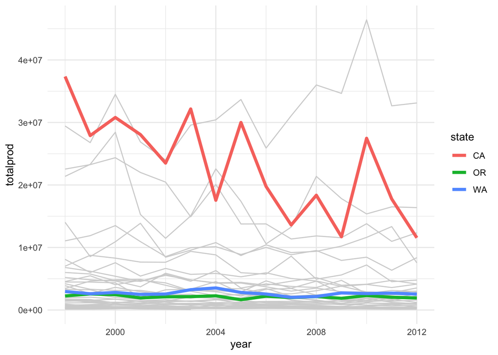

```r
p1 <- ggplot(df, aes(year, totalprod)) +
  geom_line(aes(group=state),
            color="lightgrey") +
  geom_line(data = df %>% filter(state %in% c("CA", "OR", "WA")),
            aes(color=state),
            size=1.5) +
  theme_minimal()

p1
```

### Reproduce the plot according three different kinds of color blindness, as well as a desaturated version.

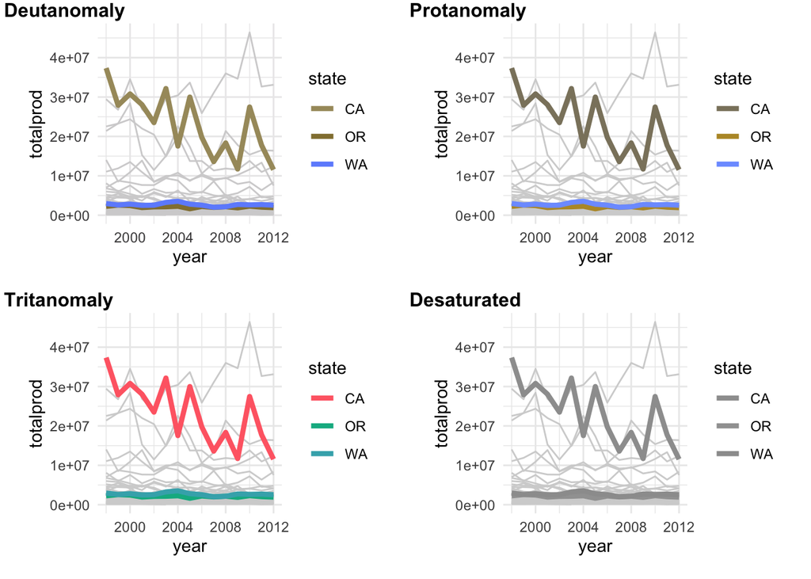

```r
cvd_grid(p1)
```

### Reproduce the plot using a color blind safe palette.

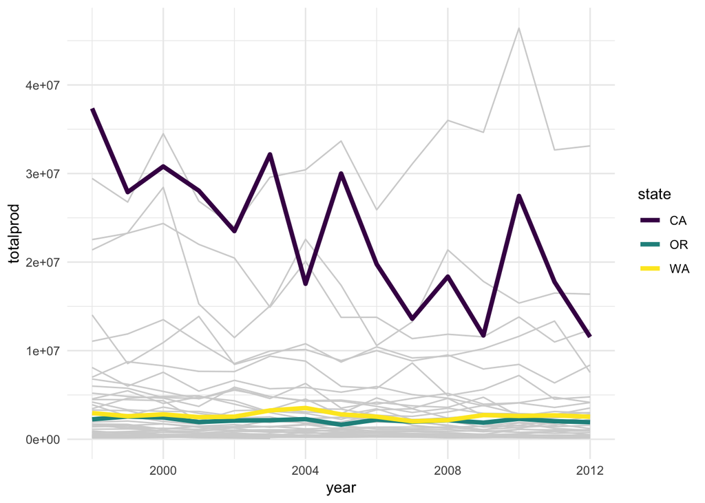

```r
p2 = p1 + scale_color_viridis_d()

p2
```

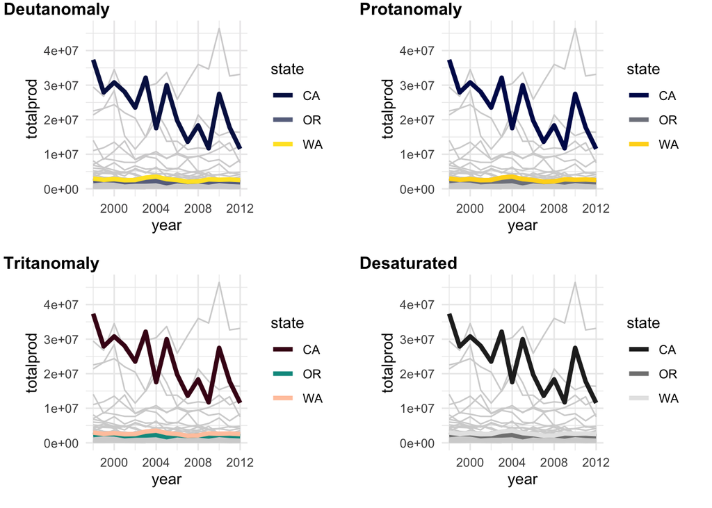

```r
cvd_grid(p2)
```

### Download the file here denoting the region and division of each state.

#### Join the file with your honey file.

```r
df2 <- read_csv(here::here("regions_divisions.txt"))
df3 <- df %>% left_join(df2, by=c("state"="State Code"))
```

#### Produce a bar plot displaying the average honey for each state (collapsing across years).

```r
df_avg = df3 %>%
  group_by(Region, state) %>%
  summarise(year_m = mean(totalprod))
```

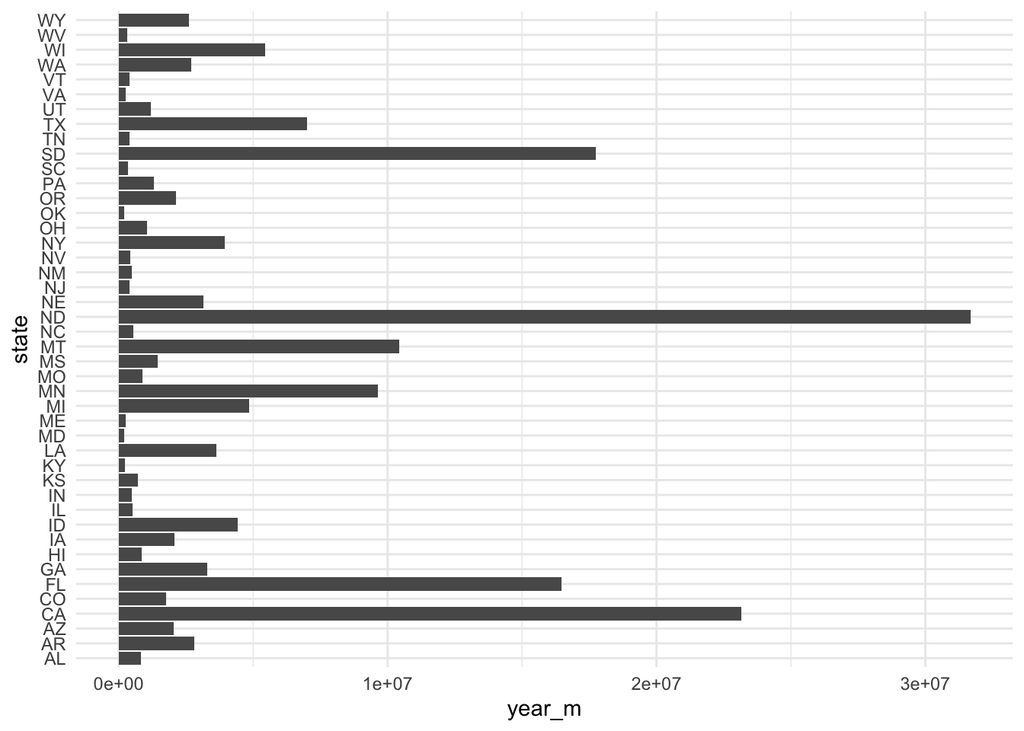

```r
ggplot(df_avg, aes(x=state, y=year_m)) +
  geom_bar(stat="identity") +
  coord_flip() +
  theme_minimal()
```

#### Use color to highlight the region of the country the state is from.

Note patterns you notice: The production of honey is an exponential distribution, and most of tail are Northeast and South.

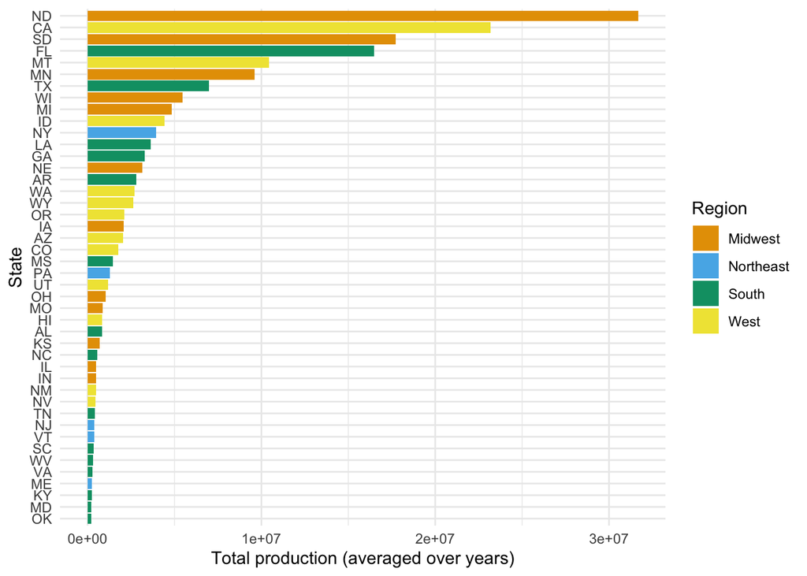

```r
ggplot(df_avg, aes(x=reorder(state, year_m),
                   y=year_m,
                   fill=Region)) +
  geom_bar(stat="identity") +
  coord_flip() +
  scale_fill_OkabeIto() +
  labs(x="State",
       y="Total production (averaged over years)") +
  theme_minimal()
```

### Create a heatmap displaying the average honey production across years by region (averaging across states within region).

```r
df_avg2 = df3 %>%
  group_by(Region, year) %>%
  summarise(year_m = mean(totalprod))
```

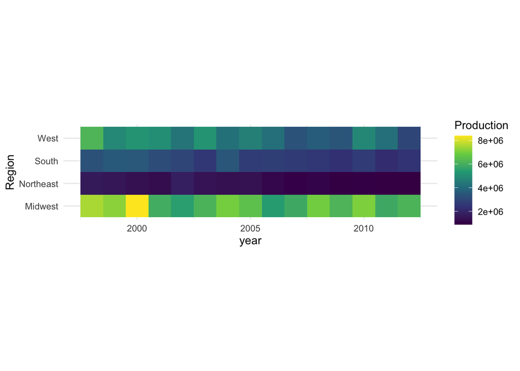

```r
ggplot(df_avg2, aes(x=year,
                    y=Region,
                    fill=year_m)) +
  geom_tile() +
  scale_fill_viridis_c() +
  labs(fill = "Production") +
  coord_fixed() +
  theme_minimal()
```

### Create at least one more plot of your choosing using color to distinguish, represent data values, or highlight.

I tried for a while but had difficulties in installing the “albersusa” package, which seems to be caused by a failure to install the “units” package. When I tried to install the “unit” manually, the error message says I need the “libudunits2.so” to install the “units”, so I tried to install udunits through command line. Then the command line says it was installed already, so I am a bit run out of ideas for the installation.

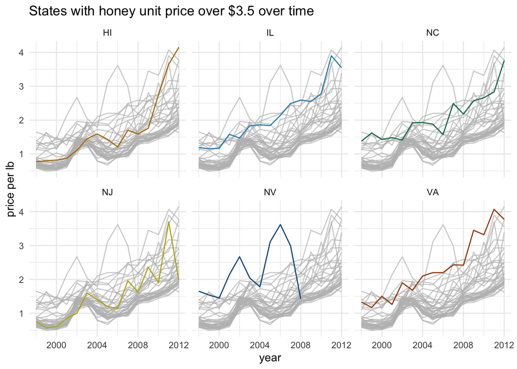

```r
df_avg3 = df3 %>%
  group_by(state) %>%
  summarise(m=mean(priceperlb))

ggplot(df3, aes(year,
                priceperlb,
                color=state)) +
  geom_line(aes(group=state)) +
  facet_wrap(~state)+
  gghighlight(max(priceperlb) > 3.5,
              use_direct_label=FALSE) +
  scale_color_OkabeIto(darken = 0.2) +
  theme_minimal() +
  labs(title = "States with honey unit price over $3.5 over time",
       y = "price per lb") +
  theme(legend.position = "none")
```